# Lab 9: Instrumental Variable Analysis

## 1. Question 1 — Association of Lucent Area with Genotype

We begin by testing whether the proposed instrument `igfbp3g` is associated with the outcome `log(lucent)`. Under the IV assumptions, any such association can only arise through the exposure `igfbp3`. A significant association is therefore consistent with (but does not prove) the existence of a causal effect of IGFBP-3 on breast density.

```r
# ── Linear trend ──────────────────────────────────────────────────────────────
lm_q1 <- lm(log_lucent ~ igfbp3g_num, data = data)
summary(lm_q1)
```

```
##
## Call:
## lm(formula = log_lucent ~ igfbp3g_num, data = data)
##
## Residuals:
##      Min       1Q   Median       3Q      Max
## -1.53056 -0.33987  0.02139  0.37386  1.52820
##
## Coefficients:
##             Estimate Std. Error t value Pr(>|t|)
## (Intercept)  4.43102    0.20365  21.758   <2e-16 ***
## igfbp3g_num -0.15431    0.06468  -2.386   0.0184 *
## ---
## Signif. codes:  0 '***' 0.001 '**' 0.01 '*' 0.05 '.' 0.1 ' ' 1
##
## Residual standard error: 0.5504 on 137 degrees of freedom
## Multiple R-squared:  0.03989,    Adjusted R-squared:  0.03288
## F-statistic: 5.691 on 1 and 137 DF,  p-value: 0.01842
```

```r
# ── Factor model (no ordering assumed) ───────────────────────────────────────
lm_q1_cat <- lm(log_lucent ~ factor(igfbp3g), data = data)
summary(lm_q1_cat)
```

```
##
## Call:
## lm(formula = log_lucent ~ factor(igfbp3g), data = data)
##
## Residuals:
##      Min       1Q   Median       3Q      Max
## -1.47565 -0.34118  0.01246  0.39445  1.45999
##
## Coefficients:
##                    Estimate Std. Error t value Pr(>|t|)
## (Intercept)         4.05207    0.09696  41.790   <2e-16 ***
## factor(igfbp3g)A/C -0.01574    0.11815  -0.133    0.894
## factor(igfbp3g)C/C -0.29317    0.12938  -2.266    0.025 *
## ---
## Signif. codes:  0 '***' 0.001 '**' 0.01 '*' 0.05 '.' 0.1 ' ' 1
##
## Residual standard error: 0.5485 on 136 degrees of freedom
## Multiple R-squared:  0.05351,    Adjusted R-squared:  0.03959
## F-statistic: 3.845 on 2 and 136 DF,  p-value: 0.02376
```

```r
# ── Pearson correlation ───────────────────────────────────────────────────────
cor.test(data$log_lucent, data$igfbp3g_num)
```

```
##
##  Pearson's product-moment correlation
##
## data:  data$log_lucent and data$igfbp3g_num
## t = -2.3856, df = 137, p-value = 0.01842
## alternative hypothesis: true correlation is not equal to 0
## 95 percent confidence interval:
##  -0.35442886 -0.03435528
## sample estimates:
##        cor
## -0.1997137
```

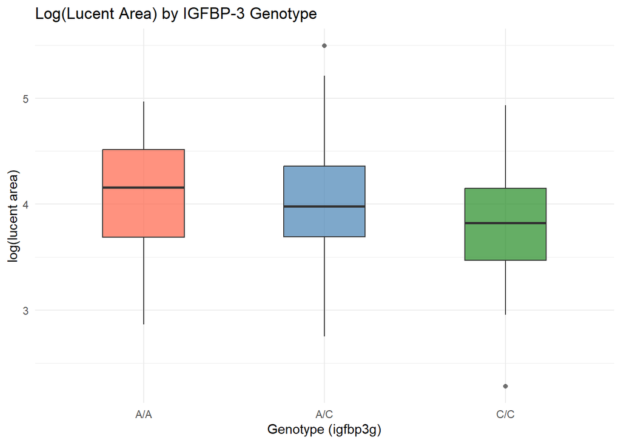

```r
# ── Visualise ────────────────────────────────────────────────────────────────
ggplot(data, aes(x = igfbp3g, y = log_lucent, fill = igfbp3g)) +
  geom_boxplot(alpha = 0.7, outlier.shape = 16, width = 0.45) +
  scale_fill_manual(values = c("tomato", "steelblue", "forestgreen")) +
  theme_minimal() +
  labs(x = "Genotype (igfbp3g)", y = "log(lucent area)",
       title = "Log(Lucent Area) by IGFBP-3 Genotype") +
  theme(legend.position = "none")
```

> **Interpretation:** The genotype is significantly associated with log(lucent area) ($p = 0.018$), with each additional C allele corresponding to a decrease in log-lucent area of approximately 0.154. Under the IV assumptions, this association propagates entirely through IGFBP-3 levels — consistent with the instrument having a causal downstream effect.

## 2. Question 2 — Distribution of IGFBP-3 and Relevance of the Instrument

We examine the distribution of the exposure and assess whether the instrument satisfies the **relevance** assumption — i.e., whether `igfbp3g` is associated with serum IGFBP-3 after (implicitly) adjusting for measured confounders. This is the only IV assumption directly testable from data.

### 2.1 Histogram of IGFBP-3 (raw and log-transformed)

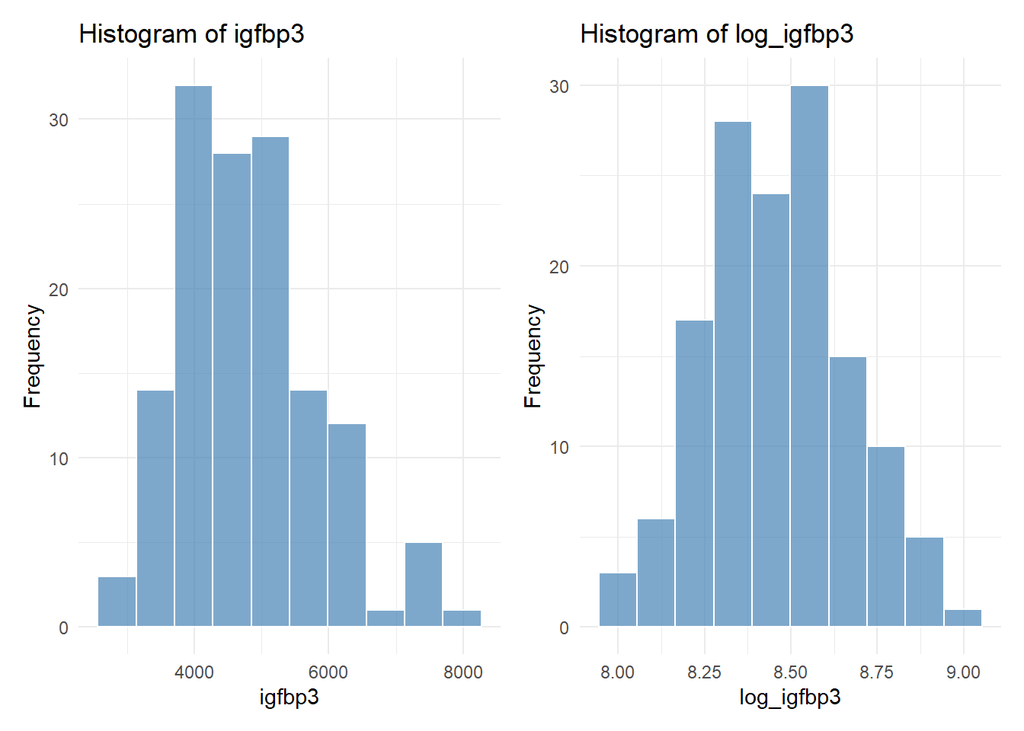

```r
p1 <- ggplot(data, aes(x = igfbp3)) +
  geom_histogram(bins = 10, fill = "steelblue", alpha = 0.7, color = "white") +
  theme_minimal() +
  labs(x = "igfbp3", y = "Frequency", title = "Histogram of igfbp3")

p2 <- ggplot(data, aes(x = log_igfbp3)) +
  geom_histogram(bins = 10, fill = "steelblue", alpha = 0.7, color = "white") +
  theme_minimal() +
  labs(x = "log_igfbp3", y = "Frequency", title = "Histogram of log_igfbp3")

p1 + p2
```

> The raw distribution of IGFBP-3 is right-skewed; the log transformation yields an approximately symmetric distribution, making it more suitable for linear models.

### 2.2 Distribution of log(IGFBP-3) by genotype

```r
# ── Summary statistics by genotype ────────────────────────────────────────────
data %>%
  group_by(igfbp3g) %>%
  summarise(
    n    = n(),
    mean = round(mean(log_igfbp3), 3),
    sd   = round(sd(log_igfbp3),   3),
    min  = round(min(log_igfbp3),  3),
    max  = round(max(log_igfbp3),  3)
  )
```

```
## # A tibble: 3 × 6
##   igfbp3g     n  mean    sd   min   max
##   <fct>   <int> <dbl> <dbl> <dbl> <dbl>
## 1 A/A        32  8.52 0.234  8.00  9.00
## 2 A/C        66  8.47 0.18   8.04  8.94
## 3 C/C        41  8.40 0.212  8.07  8.94
```

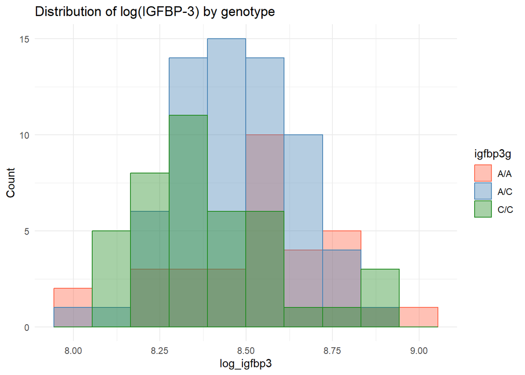

```r
# ── Overlapping histograms ────────────────────────────────────────────────────
ggplot(data, aes(x = log_igfbp3, fill = igfbp3g, colour = igfbp3g)) +
  geom_histogram(alpha = 0.4, position = "identity", bins = 10) +
  scale_fill_manual(values   = c("tomato", "steelblue", "forestgreen")) +
  scale_colour_manual(values = c("tomato", "steelblue", "forestgreen")) +
  theme_minimal() +
  labs(x = "log_igfbp3", y = "Count",
       title = "Distribution of log(IGFBP-3) by genotype",
       fill = "igfbp3g", colour = "igfbp3g")
```

### 2.3 Testing relevance

```r
# ── Linear regression of log(igfbp3) on genotype ─────────────────────────────
lm_q2 <- lm(log_igfbp3 ~ igfbp3g_num, data = data)
summary(lm_q2)
```

```
##
## Call:
## lm(formula = log_igfbp3 ~ igfbp3g_num, data = data)
##
## Residuals:
##      Min       1Q   Median       3Q      Max
## -0.52585 -0.13318 -0.01017  0.12787  0.54024
##
## Coefficients:
##             Estimate Std. Error t value Pr(>|t|)
## (Intercept)  8.65484    0.07484 115.643  < 2e-16 ***
## igfbp3g_num -0.06332    0.02377  -2.664  0.00865 **
## ---
## Signif. codes:  0 '***' 0.001 '**' 0.01 '*' 0.05 '.' 0.1 ' ' 1
##
## Residual standard error: 0.2023 on 137 degrees of freedom
## Multiple R-squared:  0.04925,    Adjusted R-squared:  0.04231
## F-statistic: 7.096 on 1 and 137 DF,  p-value: 0.008652
```

```r
# ── As factor, with F-test ────────────────────────────────────────────────────
lm_q2_cat <- lm(log_igfbp3 ~ factor(igfbp3g), data = data)
anova(lm_q2_cat)
```

```
## Analysis of Variance Table
##
## Response: log_igfbp3
##                  Df Sum Sq  Mean Sq F value  Pr(>F)
## factor(igfbp3g)   2 0.2979 0.148932  3.6183 0.02944 *
## Residuals       136 5.5978 0.041161
## ---
## Signif. codes:  0 '***' 0.001 '**' 0.01 '*' 0.05 '.' 0.1 ' ' 1
```

> **Interpretation:** The genotype is significantly associated with log(IGFBP-3) ($p = 0.009$), supporting the relevance assumption. Each additional C allele is associated with a decrease of approximately 0.063 in log(IGFBP-3). This is the only IV assumption directly testable from data; the exclusion restriction and randomization assumption require subject-matter justification.

## 3. Question 3 — DAG and IV Assumptions

```r
grViz("
digraph IV_DAG {
  graph [layout = neato, bgcolor = transparent, splines = curved]
  node [shape = plaintext, fontname = 'Helvetica', fontsize = 16]
  R [pos = '0,0!',  label = 'R\n(igfbp3g)']
  A [pos = '3,0!',  label = 'A\n(log igfbp3)']
  Y [pos = '6,0!',  label = 'Y\n(log lucent)']
  U [pos = '4.5,2!', label = 'U']
  L [pos = '3,-2!', label = 'L\n(age, afbcat,\nbrfcat, parcat, ev_pil)']

  edge [arrowhead = vee, arrowsize = 0.8, penwidth = 1.6, color = '#444444']
  R -> A
  A -> Y
  U -> A
  U -> Y
  L -> A
  L -> Y

  edge [arrowhead = vee, arrowsize = 0.7, penwidth = 1.2,
        style = dashed, color = '#888888']
  R -> Y [style = dashed, constraint = false]
  R -> L [style = dashed]
}
")
```

[interactive chart not shown]

The three IV assumptions in this setting are:

1. **Relevance** $R \not\!\perp\!\!\!\perp A (\mid L)$: The IGFBP3g genotype must be associated with serum IGFBP-3 levels (after adjusting for observed covariates $L$). This was verified empirically in Question 2.
2. **Exclusion restriction** $R \perp\!\!\!\perp Y \mid A, (L), U$: The genotype should not affect dense breast tissue area through any pathway other than serum IGFBP-3. This assumption is *potentially violated* if the genotype affects fertility-related traits (such as parity or age at first birth), which in turn influence breast tissue density.
3. **Randomization** $R \perp\!\!\!\perp U (\mid L)$: The genotype is randomized by Mendelian inheritance — transmission of alleles from parent to offspring is random, so it should not share common causes with the unmeasured confounders $U$ (after conditioning on $L$). This assumption is not testable from data and relies on biological reasoning.

## 4. Question 4 — IV Estimate via Efficient Influence Function (no covariates)

We estimate $\psi$ using the EIF estimator without adjusting for any covariates $L$. In this case $\hat{E}(R \mid L) = \bar{R}$, $\hat{E}(A \mid L) = \bar{A}$, and $\hat{E}(Y \mid L) = \bar{Y}$, so the estimator reduces to:

$$\hat{\psi} =
\frac{\sum_i (R_i - \bar{R})(Y_i - \bar{Y})}
{\sum_i (R_i - \bar{R})(A_i - \bar{A})}$$

```r
# ── Point estimate ────────────────────────────────────────────────────────────
beta_q4 <- mean((R - mean(R)) * (Y - mean(Y))) /
           mean((R - mean(R)) * (A - mean(A)))

# ── Standard error via influence function ─────────────────────────────────────
EIC_beta_q4 <- (R - mean(R)) * (Y - mean(Y) - beta_q4 * (A - mean(A))) /
               mean((R - mean(R)) * (A - mean(A)))
se_beta_q4  <- sd(EIC_beta_q4) / sqrt(N)

# ── 95% confidence interval ───────────────────────────────────────────────────
beta_q4_lb <- beta_q4 - 1.96 * se_beta_q4
beta_q4_ub <- beta_q4 + 1.96 * se_beta_q4

# ── Results on geometric mean ratio scale (10% increase in A) ─────────────────
results_q4 <- tibble(
  Method   = "EIF (no covariates)",
  Estimate = round(exp(beta_q4    * log(1.1)), 3),
  CI_Lower = round(exp(beta_q4_lb * log(1.1)), 3),
  CI_Upper = round(exp(beta_q4_ub * log(1.1)), 3)
)

# ── 2SLS comparison (no covariates) ──────────────────────────────────────────
iv_q4    <- ivreg(log_lucent ~ log_igfbp3 | igfbp3g_num, data = data)
iv_q4_ct <- coeftest(iv_q4, vcov = sandwich)
iv_q4_ci <- coefci(iv_q4,   vcov = sandwich)["log_igfbp3", ]

beta_q4_2sls    <- iv_q4_ct["log_igfbp3", 1]
beta_q4_2sls_lb <- iv_q4_ci[1]
beta_q4_2sls_ub <- iv_q4_ci[2]

results_q4 <- rbind(results_q4, tibble(
  Method   = "2SLS (no covariates)",
  Estimate = round(exp(beta_q4_2sls    * log(1.1)), 3),
  CI_Lower = round(exp(beta_q4_2sls_lb * log(1.1)), 3),
  CI_Upper = round(exp(beta_q4_2sls_ub * log(1.1)), 3)
))

knitr::kable(results_q4, digits = 3,
             caption = "Q4 — EIF vs 2SLS (no covariates): GMR for 10% increase in IGFBP-3")
```

Q4 — EIF vs 2SLS (no covariates): GMR for 10% increase in IGFBP-3

| Method | Estimate | CI_Lower | CI_Upper |
| --- | --- | --- | --- |
| EIF (no covariates) | 1.261 | 1.001 | 1.589 |
| 2SLS (no covariates) | 1.261 | 1.000 | 1.591 |

> **Interpretation:** A 10% increase in serum IGFBP-3 multiplies the geometric mean of dense breast tissue area by approximately $1.1^{\hat\psi} \approx 1.261$, i.e. an increase of roughly 26.1% [95% CI: 0.1% to 58.9%]. The confidence interval is wide, reflecting the limited sample size and weak instrument strength.

## 5. Question 5 — DML IV Estimate with Covariates (SuperLearner)

A concern with the unadjusted IV estimate is that `parcat` and `afbcat` (parity and age at first birth) may lie on the causal pathway from genotype to outcome — violating the exclusion restriction. We address this by conditioning on $L = (\texttt{afbcat}, \texttt{parcat})$, thereby blocking that pathway.

We use **Debiased Machine Learning** with SuperLearner to estimate the three nuisance functions $\hat{E}(Y \mid L)$, $\hat{E}(A \mid L)$ and $\hat{E}(R \mid L)$. Given the small sample ($n = 139$), cross-fitting is omitted and a restricted library is used.

```r
# ── Confounder set blocking the problematic pathway ───────────────────────────
L_5 <- data %>% dplyr::select(afbcat, parcat)

SL.library <- c("SL.glm", "SL.ranger", "SL.earth")

# ── Nuisance models ───────────────────────────────────────────────────────────
sl_Y_q5 <- SuperLearner(Y = Y, X = L_5, SL.library = SL.library)
sl_A_q5 <- SuperLearner(Y = A, X = L_5, SL.library = SL.library)
sl_R_q5 <- SuperLearner(Y = R, X = L_5, SL.library = SL.library)

# ── Nuisance predictions ──────────────────────────────────────────────────────
m_Y_q5 <- predict(sl_Y_q5, newdata = L_5, onlySL = TRUE)$pred
m_A_q5 <- predict(sl_A_q5, newdata = L_5, onlySL = TRUE)$pred
m_R_q5 <- predict(sl_R_q5, newdata = L_5, onlySL = TRUE)$pred

# ── EIF estimator with covariates ─────────────────────────────────────────────
beta_q5 <- mean((R - m_R_q5) * (Y - m_Y_q5)) /
           mean((R - m_R_q5) * (A - m_A_q5))

# ── Standard error ────────────────────────────────────────────────────────────
EIC_beta_q5 <- (R - m_R_q5) * (Y - m_Y_q5 - beta_q5 * (A - m_A_q5)) /
               mean((R - m_R_q5) * (A - m_A_q5))
se_beta_q5  <- sd(EIC_beta_q5) / sqrt(N)

# ── 95% confidence interval ───────────────────────────────────────────────────
beta_q5_lb <- beta_q5 - 1.96 * se_beta_q5
beta_q5_ub <- beta_q5 + 1.96 * se_beta_q5

# ── Results ───────────────────────────────────────────────────────────────────
results_q5 <- tibble(
  Method   = "EIF (afbcat + parcat)",
  Estimate = round(exp(beta_q5    * log(1.1)), 3),
  CI_Lower = round(exp(beta_q5_lb * log(1.1)), 3),
  CI_Upper = round(exp(beta_q5_ub * log(1.1)), 3)
)

# ── 2SLS comparison (afbcat + parcat) ────────────────────────────────────────
iv_q5    <- ivreg(log_lucent ~ log_igfbp3 + afbcat + parcat |
                    igfbp3g_num + afbcat + parcat, data = data)
iv_q5_ct <- coeftest(iv_q5, vcov = sandwich)
iv_q5_ci <- coefci(iv_q5,   vcov = sandwich)["log_igfbp3", ]

beta_q5_2sls    <- iv_q5_ct["log_igfbp3", 1]
beta_q5_2sls_lb <- iv_q5_ci[1]
beta_q5_2sls_ub <- iv_q5_ci[2]

results_q5 <- rbind(results_q5, tibble(
  Method   = "2SLS (afbcat + parcat)",
  Estimate = round(exp(beta_q5_2sls    * log(1.1)), 3),
  CI_Lower = round(exp(beta_q5_2sls_lb * log(1.1)), 3),
  CI_Upper = round(exp(beta_q5_2sls_ub * log(1.1)), 3)
))

knitr::kable(results_q5, digits = 3,
             caption = "Q5 — EIF vs 2SLS (afbcat + parcat): GMR for 10% increase in IGFBP-3")
```

Q5 — EIF vs 2SLS (afbcat + parcat): GMR for 10% increase in IGFBP-3

| Method | Estimate | CI_Lower | CI_Upper |
| --- | --- | --- | --- |
| EIF (afbcat + parcat) | 1.268 | 1.014 | 1.585 |
| 2SLS (afbcat + parcat) | 1.249 | 1.033 | 1.511 |

## 6. Question 6 — Assumption-Lean Regression (Comparison)

For comparison, we estimate the **association** (not necessarily causal effect) between log(IGFBP-3) and log(lucent area) using **assumption-lean linear regression** — adjusting for the full confounder set $L = (\texttt{age}, \texttt{afbcat}, \texttt{brfcat}, \texttt{parcat}, \texttt{ev\_pil})$.

```r
# ── Full confounder set ───────────────────────────────────────────────────────
L_6 <- data %>% dplyr::select(age, afbcat, brfcat, parcat, ev_pil)

# ── Nuisance models ───────────────────────────────────────────────────────────
sl_Y_q6 <- SuperLearner(Y = Y, X = L_6, SL.library = SL.library)
sl_A_q6 <- SuperLearner(Y = A, X = L_6, SL.library = SL.library)

m_Y_q6 <- predict(sl_Y_q6, newdata = L_6, onlySL = TRUE)$pred
m_A_q6 <- predict(sl_A_q6, newdata = L_6, onlySL = TRUE)$pred

# ── EIF estimator ──────────────────────────────────────────────────
A_res <- A - m_A_q6
Y_res <- Y - m_Y_q6

beta_q6 <- mean(A_res * Y_res) / mean(A_res^2)

# ── Standard error via influence function ─────────────────────────────────────
EIC_beta_q6 <- A_res * (Y_res - beta_q6 * A_res) / mean(A_res^2)
se_beta_q6  <- sd(EIC_beta_q6) / sqrt(N)

# ── 95% CI ────────────────────────────────────────────────────────────────────
beta_q6_lb <- beta_q6 - 1.96 * se_beta_q6
beta_q6_ub <- beta_q6 + 1.96 * se_beta_q6

# ── Results ───────────────────────────────────────────────────────────────────
results_q6 <- tibble(
  Method   = "Assumption-lean regression (full L)",
  Estimate = round(exp(beta_q6    * log(1.1)), 3),
  CI_Lower = round(exp(beta_q6_lb * log(1.1)), 3),
  CI_Upper = round(exp(beta_q6_ub * log(1.1)), 3)
)

knitr::kable(results_q6, digits = 3,
             caption = "Q6 — Assumption-lean regression: GMR for 10% increase in IGFBP-3")
```

Q6 — Assumption-lean regression: GMR for 10% increase in IGFBP-3

| Method | Estimate | CI_Lower | CI_Upper |
| --- | --- | --- | --- |
| Assumption-lean regression (full L) | 1.046 | 1.001 | 1.094 |

## 7. Summary of Results

```r
results_all <- tibble(
  Method = c(
    "IV — EIF (no covariates)",
    "IV — 2SLS (no covariates)",
    "IV — EIF (afbcat + parcat)",
    "IV — 2SLS (afbcat + parcat)",
    "Assumption-lean regression (full L)"
  ),
  Type = c("IV", "IV", "IV", "IV", "Regression"),
  Estimate = exp(c(beta_q4, beta_q4_2sls, beta_q5, beta_q5_2sls, beta_q6) * log(1.1)),
  Lower    = exp(c(beta_q4_lb, beta_q4_2sls_lb, beta_q5_lb, beta_q5_2sls_lb, beta_q6_lb) * log(1.1)),
  Upper    = exp(c(beta_q4_ub, beta_q4_2sls_ub, beta_q5_ub, beta_q5_2sls_ub, beta_q6_ub) * log(1.1))
)

knitr::kable(results_all, digits = 3,
             caption = "All estimates: GMR for a 10% increase in IGFBP-3")
```

All estimates: GMR for a 10% increase in IGFBP-3

| Method | Type | Estimate | Lower | Upper |
| --- | --- | --- | --- | --- |
| IV — EIF (no covariates) | IV | 1.261 | 1.001 | 1.589 |
| IV — 2SLS (no covariates) | IV | 1.261 | 1.000 | 1.591 |
| IV — EIF (afbcat + parcat) | IV | 1.268 | 1.014 | 1.585 |
| IV — 2SLS (afbcat + parcat) | IV | 1.249 | 1.033 | 1.511 |
| Assumption-lean regression (full L) | Regression | 1.046 | 1.001 | 1.094 |

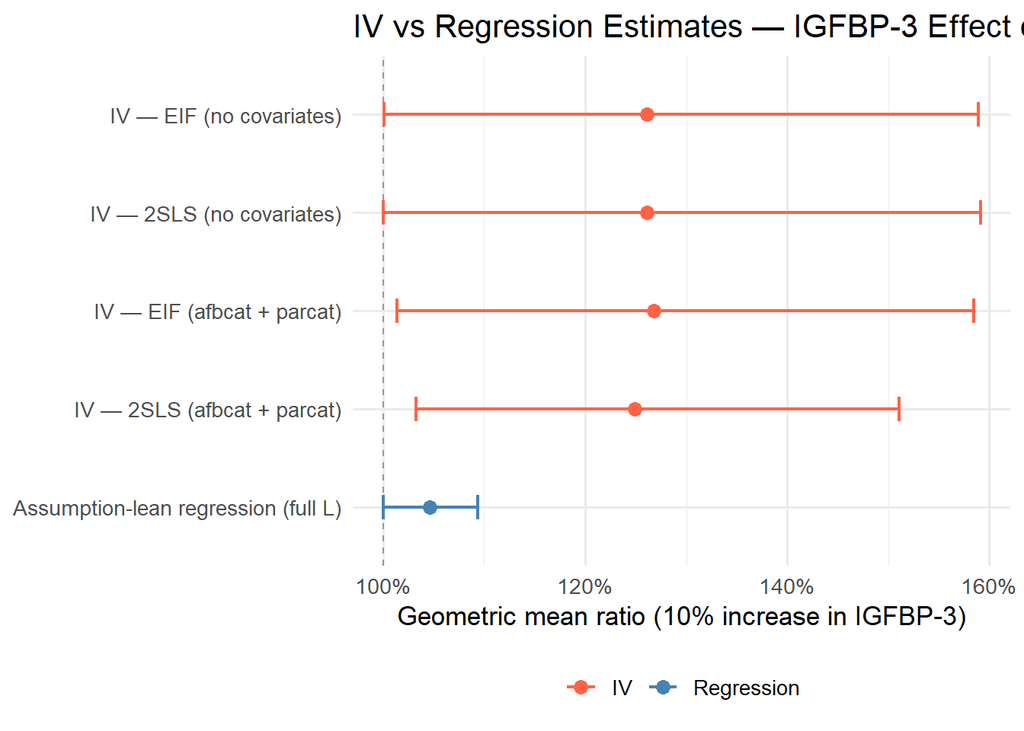

```r
results_all %>%
  mutate(Method = factor(Method, levels = rev(Method))) %>%
  ggplot(aes(x = Estimate, y = Method, colour = Type)) +
  geom_vline(xintercept = 1, linetype = "dashed", colour = "grey60") +
  geom_errorbarh(aes(xmin = Lower, xmax = Upper), height = 0.25, linewidth = 0.8) +
  geom_point(size = 3) +
  scale_x_continuous(labels = scales::percent_format(accuracy = 1, scale = 100)) +
  scale_colour_manual(values = c("IV" = "tomato", "Regression" = "steelblue")) +
  theme_minimal(base_size = 13) +
  labs(
    x      = "Geometric mean ratio (10% increase in IGFBP-3)",
    y      = NULL,
    colour = NULL,
    title  = "IV vs Regression Estimates — IGFBP-3 Effect on Breast Density"
  ) +
  theme(legend.position = "bottom")
```

> **Overall conclusion:** The IV estimates suggest a substantial positive causal effect of serum IGFBP-3 on dense breast tissue area. A 10% increase in IGFBP-3 multiplies the geometric mean lucent area by roughly $1.1^\psi \approx 1.26$, i.e. an increase of $\sim 26\%$. The assumption-lean regression estimate is substantially smaller, pointing to negative unmeasured confounding that masks the causal effect in a standard observational analysis.